# Dana 4820-001 Final Project Customer Subscription

## Predicting Whether The Customer Will Subscribe To Term Deposit

Nowadays, marketing spending in the banking industry is massive, meaning that it is essential for banks to optimize marketing strategies and improve effectiveness. Understanding customers’ need leads to more effective marketing plans, smarter product designs and greater customer satisfaction.

This project will enable the bank to develop a more granular understanding of its customer base, predict customers’ response to its telemarketing campaign and establish a target customer profile for future marketing plans.

By analyzing customer features, such as demographics and transaction history, the bank will be able to predict customer saving behaviours and identify which type of customers is more likely to make term deposits. The bank can then focus its marketing efforts on those customers. This will not only allow the bank to secure deposits more effectively but also increase customer satisfaction by reducing undesirable advertisements for certain customers.

### Attribute Information:¶

- age (numeric)
- job : type of job (categorical: ‘admin.’,’bluecollar’,’entrepreneur’,’housemaid’,’management’,’retired’,’selfemployed’,’services’,’student’,’technician’,’unemployed’,’unknown’)
- marital : marital status (categorical: ‘divorced’,’married’,’single’,’unknown’; note: ‘divorced’ means divorced or widowed)
- education (categorical:‘basic.4y’,’basic.6y’,’basic.9y’,’high.school’,’illiterate’,’professional.course’,’university.degree’,’unknown’)
- default: has credit in default? (categorical: ‘no’,’yes’,’unknown’)
- balance: average yearly balance, in euros (numeric)
- housing: has housing loan? (categorical: ‘no’,’yes’,’unknown’)
- loan: has personal loan? (categorical: ‘no’,’yes’,’unknown’)
- contact: contact communication type (categorical: ‘cellular’,’telephone’)
- day: last contact day of the month (numeric 1 -31)
- month: last contact month of year (categorical: ‘jan’, ‘feb’, ‘mar’, …, ‘nov’, ‘dec’)
- duration: last contact duration, in seconds (numeric). Important note: this attribute highly affects the output target (e.g., if duration=0 then y=’no’). Yet,the duration is not known before a call is performed. Also, after the end of the call y is obviously known. Thus, this input should only be included for benchmark purposes and should be discarded if the intention is to have a realistic predictive model.
- campaign: number of contacts performed during this campaign and for this client (numeric, includes last contact)
- pdays: number of days that passed by after the client was last contacted from a previous campaign (numeric; -1 means client was not previously contacted)
- previous: number of contacts performed before this campaign and for this client (numeric)
- poutcome: outcome of the previous marketing campaign (categorical:‘failure’,’nonexistent’,’success’)
- target: has the client subscribed a term deposit? (binary: “yes”,”no”)

#### Loading Libraries:

```r
library(tidyverse)
library(hrbrthemes)
library(viridis)
#library(Johnson)
library(tidyverse)
library(fastDummies)
library(MASS)
library(caret)
library(leaps)
library(here)
library(skimr)
library(janitor)
library(lubridate)
library(LaplacesDemon)
library(WVPlots)
library(praznik)
library(standardize)
library(clusterSim)
library(dplyr)
library(reshape2)
library(caTools)
library(ggcorrplot)
library(Metrics)
library(car)
library(olsrr)
library(PerformanceAnalytics)
library(sjPlot)
library(sjmisc)
library(ggplot2)
theme_set(theme_sjplot())
```

#### Read Dataset

The dataset has been uploaded here. A first glimpse of variables is observed by considering head of the dataset.

```r
df_loan <- read.csv("../dataset/train.csv")
head(df_loan)
```

|  | ID | age | job | marital | education | default | balance | housing | loan | contact | day | month | duration | campaign | pdays | previous | poutcome | subscribed |
| --- | --- | --- | --- | --- | --- | --- | --- | --- | --- | --- | --- | --- | --- | --- | --- | --- | --- | --- |
| 1 | 26110 | 56 | admin. | married | unknown | no | 1933 | no | no | telephone | 19 | nov | 44 | 2 | -1 | 0 | unknown | no |
| 2 | 40576 | 31 | unknown | married | secondary | no | 3 | no | no | cellular | 20 | jul | 91 | 2 | -1 | 0 | unknown | no |
| 3 | 15320 | 27 | services | married | secondary | no | 891 | yes | no | cellular | 18 | jul | 240 | 1 | -1 | 0 | unknown | no |
| 4 | 43962 | 57 | management | divorced | tertiary | no | 3287 | no | no | cellular | 22 | jun | 867 | 1 | 84 | 3 | success | yes |
| 5 | 29842 | 31 | technician | married | secondary | no | 119 | yes | no | cellular | 4 | feb | 380 | 1 | -1 | 0 | unknown | no |
| 6 | 29390 | 33 | management | single | tertiary | no | 0 | yes | no | cellular | 2 | feb | 116 | 3 | -1 | 0 | unknown | no |

#### Datatypes

The types of variables is checked by observing the structure of data set. A list of variables with is type has been shown as:

```r
str(df_loan)
```

```
'data.frame':   31647 obs. of  18 variables:
 $ ID        : int  26110 40576 15320 43962 29842 29390 40444 40194 29824 44676 ...
 $ age       : int  56 31 27 57 31 33 56 50 45 35 ...
 $ job       : chr  "admin." "unknown" "services" "management" ...
 $ marital   : chr  "married" "married" "married" "divorced" ...
 $ education : chr  "unknown" "secondary" "secondary" "tertiary" ...
 $ default   : chr  "no" "no" "no" "no" ...
 $ balance   : int  1933 3 891 3287 119 0 1044 1811 1951 1204 ...
 $ housing   : chr  "no" "no" "yes" "no" ...
 $ loan      : chr  "no" "no" "no" "no" ...
 $ contact   : chr  "telephone" "cellular" "cellular" "cellular" ...
 $ day       : int  19 20 18 22 4 2 3 8 4 3 ...
 $ month     : chr  "nov" "jul" "jul" "jun" ...
 $ duration  : int  44 91 240 867 380 116 353 97 692 789 ...
 $ campaign  : int  2 2 1 1 1 3 2 4 1 2 ...
 $ pdays     : int  -1 -1 -1 84 -1 -1 -1 -1 -1 -1 ...
 $ previous  : int  0 0 0 3 0 0 0 0 0 0 ...
 $ poutcome  : chr  "unknown" "unknown" "unknown" "success" ...
 $ subscribed: chr  "no" "no" "no" "yes" ...
```

Out of total 18 variables; ID, age, day, balance, duration, campaign, pdays and previous are integer or numerical types. All other variables are categorical with character data type.

#### Summary

```r
summary(df_loan)
```

```
       ID             age            job              marital           education           default             balance
 Min.   :    2   Min.   :18.00   Length:31647       Length:31647       Length:31647       Length:31647       Min.   : -8019
 1st Qu.:11218   1st Qu.:33.00   Class :character   Class :character   Class :character   Class :character   1st Qu.:    73
 Median :22519   Median :39.00   Mode  :character   Mode  :character   Mode  :character   Mode  :character   Median :   450
 Mean   :22564   Mean   :40.96                                                                               Mean   :  1364
 3rd Qu.:33880   3rd Qu.:48.00                                                                               3rd Qu.:  1431
 Max.   :45211   Max.   :95.00                                                                               Max.   :102127
   housing              loan             contact               day           month              duration         campaign
 Length:31647       Length:31647       Length:31647       Min.   : 1.00   Length:31647       Min.   :   0.0   Min.   : 1.000
 Class :character   Class :character   Class :character   1st Qu.: 8.00   Class :character   1st Qu.: 104.0   1st Qu.: 1.000
 Mode  :character   Mode  :character   Mode  :character   Median :16.00   Mode  :character   Median : 180.0   Median : 2.000
                                                          Mean   :15.84                      Mean   : 258.1   Mean   : 2.766
                                                          3rd Qu.:21.00                      3rd Qu.: 318.5   3rd Qu.: 3.000
                                                          Max.   :31.00                      Max.   :4918.0   Max.   :63.000
     pdays           previous          poutcome          subscribed
 Min.   : -1.00   Min.   :  0.0000   Length:31647       Length:31647
 1st Qu.: -1.00   1st Qu.:  0.0000   Class :character   Class :character
 Median : -1.00   Median :  0.0000   Mode  :character   Mode  :character
 Mean   : 39.58   Mean   :  0.5743
 3rd Qu.: -1.00   3rd Qu.:  0.0000
 Max.   :871.00   Max.   :275.0000
```

outliers in campaign, pdays, previous

#### Removing ID

Since we know that less variables will give accurate results. Hence, we decided to remove ID because this is similar to index variable and it can correlate to other important numerical variables. The correlation will bias important relationships of variables. Hence, removing ID in the beginning of analysis will reduce all these difficulties.

```r
df_loan <- subset(df_loan, select = -c(ID))
head(df_loan)
```

|  | age | job | marital | education | default | balance | housing | loan | contact | day | month | duration | campaign | pdays | previous | poutcome | subscribed |
| --- | --- | --- | --- | --- | --- | --- | --- | --- | --- | --- | --- | --- | --- | --- | --- | --- | --- |
| 1 | 56 | admin. | married | unknown | no | 1933 | no | no | telephone | 19 | nov | 44 | 2 | -1 | 0 | unknown | no |
| 2 | 31 | unknown | married | secondary | no | 3 | no | no | cellular | 20 | jul | 91 | 2 | -1 | 0 | unknown | no |
| 3 | 27 | services | married | secondary | no | 891 | yes | no | cellular | 18 | jul | 240 | 1 | -1 | 0 | unknown | no |
| 4 | 57 | management | divorced | tertiary | no | 3287 | no | no | cellular | 22 | jun | 867 | 1 | 84 | 3 | success | yes |
| 5 | 31 | technician | married | secondary | no | 119 | yes | no | cellular | 4 | feb | 380 | 1 | -1 | 0 | unknown | no |
| 6 | 33 | management | single | tertiary | no | 0 | yes | no | cellular | 2 | feb | 116 | 3 | -1 | 0 | unknown | no |

#### Duration: seconds to minutes

We have changed duration of call from seconds to minutes. As this is the main variable which can affect the target variable because the longer the discussion over the phone call, higher will be chances of their interest in bank services. Changing units from seconds to minutes will give us more stable pattern.

```r
df_loan["duration"] <- df_loan["duration"]/60
```

# Visualization of Variables

The following boxplots are drawn to see the outliers among all variables. The discussion for all variables is given below: 1. Age: This variable has a range of people whose age is more than 70 which are represented by dark dots. But these are informative and near outliers. Hence, these are kept in the analysis. 2. Balance: The balance has a long range of outliers. But these are true numbers because lots of people have more funds in their bank account. These are also informative outliers. 3. Campaign: This variable is defined as number of contacts made during the campaign for particular person. These outliers have some extreme points which can affect the analysis, and handled below. 4. Duration: As discussed ablove, lots of people spend more time on call to discuss services. These are thus good outliers and are kept same. 5. Pdays:We have handled these outliers because it range is extended. These may have some influential points. 6. Previous: This varaible has few extreme outliers, so these can be handled to avoid biasing.

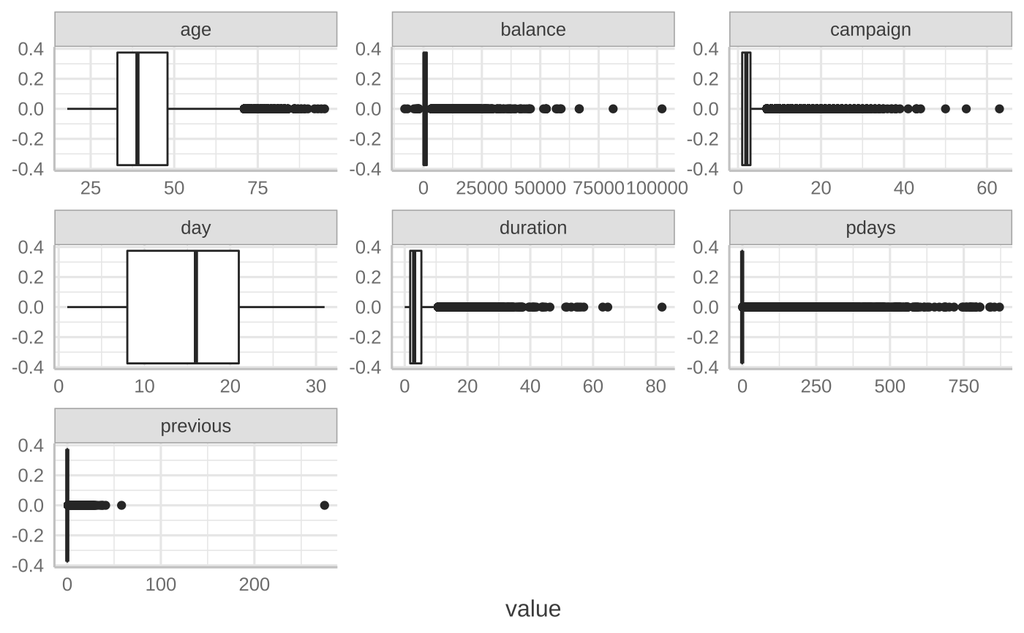

```r
df_loan %>%
  keep(is.numeric) %>%
  gather() %>%
  ggplot(aes(value)) +
  facet_wrap(~ key, scales = "free") +
  geom_boxplot()
```

#### Outliers: campaign

We have discussed above that outliers in this variable can bias the results because bank will consider all clients equally. Thus, having some customers with more campaign rate or more number of contacted times is somewhat irrelevant. We have thus capped the outliers to its 95 percentile. The normality plot shows that variable is not normally distributed.

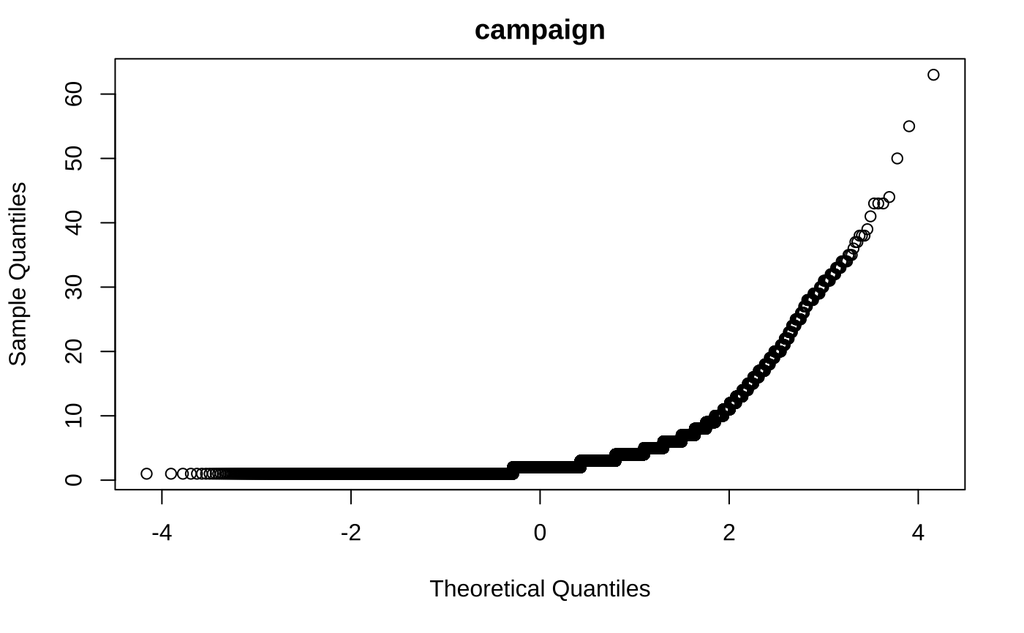

```r
qqnorm(df_loan$campaign, main = "campaign")
```

Lets handle some extreme outliers based on capping and flooring techniques:

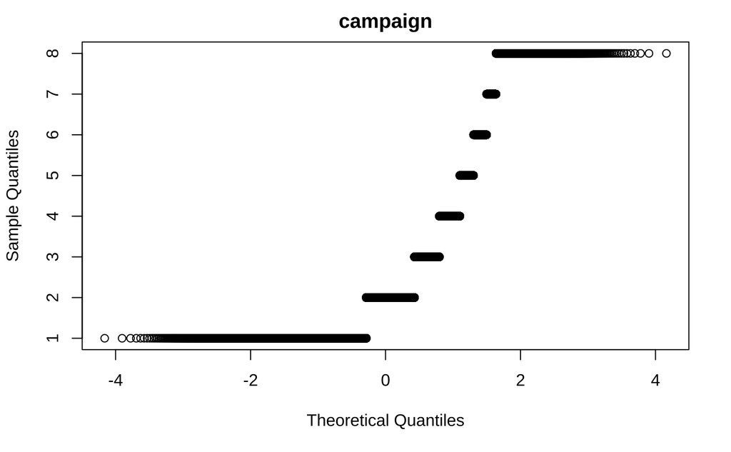

```r
df_loan$campaign[df_loan$campaign >= quantile(df_loan$campaign,0.95)] <- quantile(df_loan$campaign,0.95)
qqnorm(df_loan$campaign, main = "campaign")
```

The plot represents that all there are some chunks(or categories) in this variable.

#### Outliers: pdays

This variable is again not normally distributed as shown below:

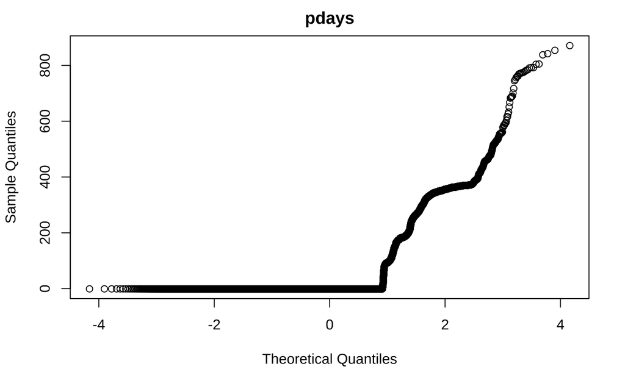

```r
qqnorm(df_loan$pdays, main = "pdays")
```

Lets find some extreme outliers based on capping and flooring techniques:

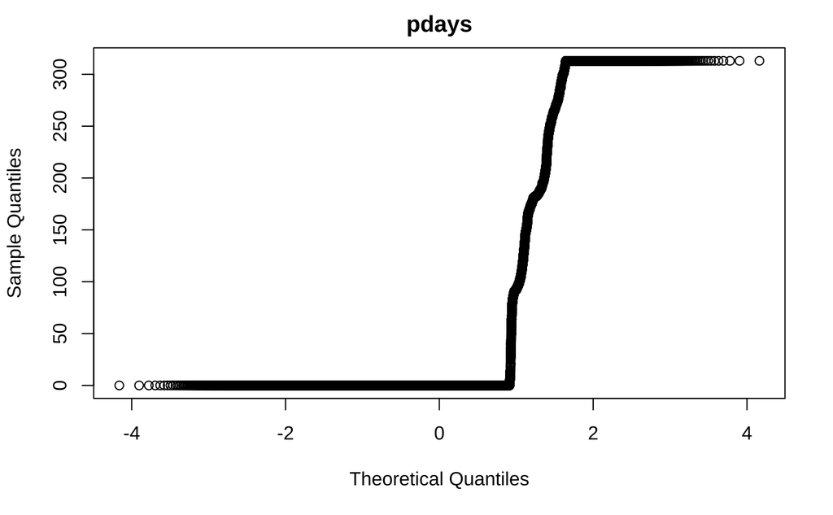

```r
df_loan$pdays[df_loan$pdays >= quantile(df_loan$pdays,0.95)] <- quantile(df_loan$pdays,0.95)
#### fixing negative values to 0
df_loan$pdays[df_loan$pdays == -1] <- 0
qqnorm(df_loan$pdays, main = "pdays")
```

The outliers are again capped to 95% value and negative 1 is replaced to 0 because days can not have negative values. It is not normally distributed.

#### Outliers: previous

The normality plot is showing some skewness and the variable is not normally distributed.

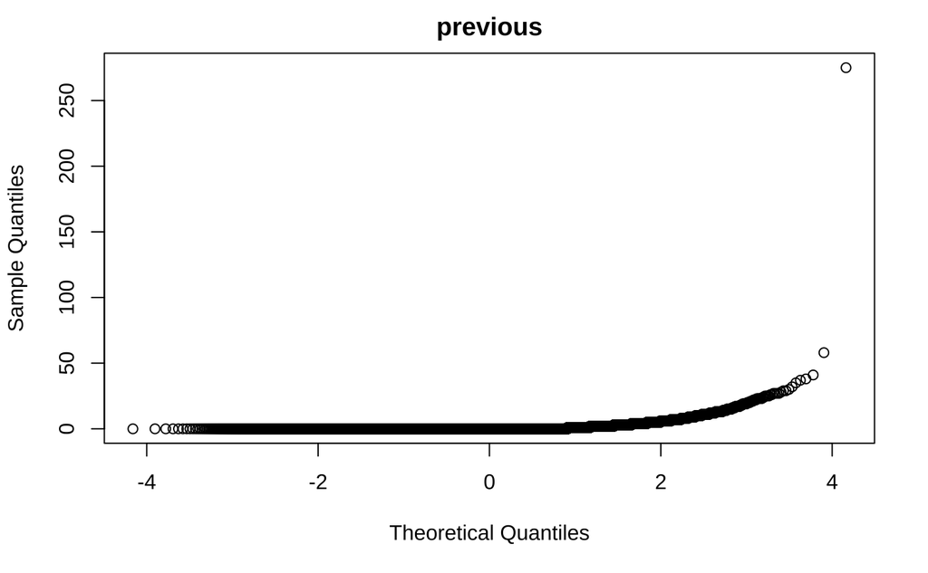

```r
qqnorm(df_loan$previous, main = "previous")
```

Lets find some extreme outliers based on capping and flooring techniques:

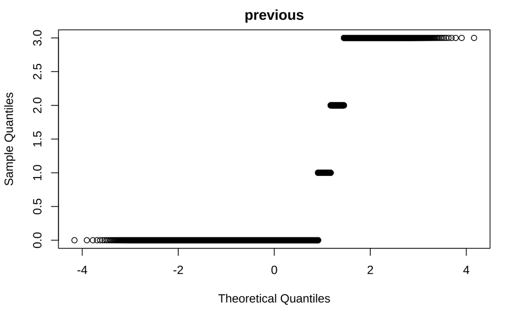

```r
df_loan$previous[df_loan$previous >= quantile(df_loan$previous,0.95)] <- quantile(df_loan$previous,0.95)
qqnorm(df_loan$previous, main = "previous")
```

This variable is again fixed by taking 95% value and the plot represents that this variable has somewhat categorical behaviour.

#### binning

We have binned the variables like campaign,pdays,previous to see some specific trends of these variables. This is done as

#### binning : campaign

We have derived 8bins of equal width.

```r
library(dlookr)
df_loan$campaign_bin <- binning(df_loan$campaign, nbins = 8, type = "equal",
                                labels = c("C1", "C2", "C3", "C4", "C5", "C6","C7","C8"))
print("campaign_eq_bins ")
```

```
[1] "campaign_eq_bins "
```

```r
df_loan$campaign_bin
```

```
binned type: equal
number of bins: 8
x
   C1    C2    C3    C4    C5    C6    C7    C8
12262  8798  3858  2442  1245   916   518  1608
```

#### binning : pdays

We have created 4bins with k-means type which usually bin range of continuous variable into groups with least within group sum of squared deviations.

```r
df_loan$pday_bin <- binning(df_loan$pdays, nbins = 4, type = "kmeans",
                            labels = c("P1", "P2", "P3", "P4"))
print("pdays_bins ")
```

```
[1] "pdays_bins "
```

```r
df_loan$pday_bin
```

```
binned type: kmeans
number of bins: 4
x
   P1    P2    P3    P4
26104  1340  1726  2477
```

#### binning : previous

We have divided in two bins with equal width technique.

```r
df_loan$previous_bin <- binning(df_loan$previous, nbins = 2, type = "equal",
                                labels = c("PR1", "PR2"))
print("previous_bin ")
```

```
[1] "previous_bin "
```

```r
df_loan$previous_bin
```

```
binned type: equal
number of bins: 2
x
  PR1   PR2
27845  3802
```

#### removing non binned variables:

We have removed non binned variables as:

```r
df_loan <- subset(df_loan, select = -c(campaign,pdays,previous))
names(df_loan)
```

```
 [1] "age"          "job"          "marital"      "education"    "default"      "balance"      "housing"      "loan"
 [9] "contact"      "day"          "month"        "duration"     "poutcome"     "subscribed"   "campaign_bin" "pday_bin"
[17] "previous_bin"
```

#### value counts for categorical variables

In this section, we have plotted boxplots for categorical variables to visualize all categories among the variables. Default, housing, loan and subscribed are binary variable and all other variables has more than two categories.

[figure not shown]

```r
df_loan %>%
  keep(is.character) %>%
  gather() %>%
  ggplot(aes(value)) +
  facet_wrap(~ key, scales = "free") +
  geom_boxplot()
```

1. Job: It has 12 categories and the value counts are shown below

```r
print("job ")
```

```
[1] "job "
```

```r
table(df_loan$job ,useNA = "ifany")
```

```
       admin.   blue-collar  entrepreneur     housemaid    management       retired self-employed      services       student
         3631          6842          1008           874          6639          1574          1123          2903           635
   technician    unemployed       unknown
         5307           905           206
```

2. Marital: It has three status which are given below wirh respective counts.

```r
print("marital ")
```

```
[1] "marital "
```

```r
table(df_loan$marital ,useNA = "ifany")
```

```
divorced  married   single
    3630    19095     8922
```

3. Education: This variable has 4 levels like primary, secondary, tertiary and unknown. the value counts are given below

```r
print("education ")
```

```
[1] "education "
```

```r
table(df_loan$education ,useNA = "ifany")
```

```
  primary secondary  tertiary   unknown
     4808     16224      9301      1314
```

4. Default: This is the binary variable with more negative response.

```r
print("default ")
```

```
[1] "default "
```

```r
table(df_loan$default ,useNA = "ifany")
```

```
   no   yes
31062   585
```

5. Housing: This is a binary variable with more positive response.

```r
print("housing ")
```

```
[1] "housing "
```

```r
table(df_loan$housing ,useNA = "ifany")
```

```
   no   yes
14063 17584
```

6. Loan: This is again binary variable and people prefer less loans.

```r
print("loan ")
```

```
[1] "loan "
```

```r
table(df_loan$loan ,useNA = "ifany")
```

```
   no   yes
26516  5131
```

7. Contact: The variable shown types of contact made based on cellular, telephone and unknown. Cellular contacts are maximum in number.

```r
print("contact ")
```

```
[1] "contact "
```

```r
table(df_loan$contact ,useNA = "ifany")
```

```
 cellular telephone   unknown
    20423      2047      9177
```

8. Months: The variable has all months and its value counts are given as:

```r
print("month ")
```

```
[1] "month "
```

```r
table(df_loan$month ,useNA = "ifany")
```

```
 apr  aug  dec  feb  jan  jul  jun  mar  may  nov  oct  sep
2055 4333  157 1827  977 4844 3738  342 9669 2783  512  410
```

9. poutcome: This variable has 4categories as shown below:

```r
print("poutcome ")
```

```
[1] "poutcome "
```

```r
table(df_loan$poutcome ,useNA = "ifany")
```

```
failure   other success unknown
   3362    1288    1068   25929
```

10. Subscribed: This is our target variable which is binary and value count shows that the subscription is less.

```r
print("subscribed ")
```

```
[1] "subscribed "
```

```r
table(df_loan$subscribed ,useNA = "ifany")
```

```
   no   yes
27932  3715
```

#### converting necessary variables to factors

We have converted all important variable including our binned variables in factors.

```r
df_loan$job <- factor(df_loan$job)
df_loan$marital <- factor(df_loan$marital)
df_loan$education <- factor(df_loan$education)
df_loan$default <- factor(df_loan$default)
df_loan$housing <- factor(df_loan$housing)
df_loan$loan <- factor(df_loan$loan)
df_loan$contact <- factor(df_loan$contact)
df_loan$month <- factor(df_loan$month)
df_loan$campaign_bin <- factor(df_loan$campaign_bin)
df_loan$pday_bin <- factor(df_loan$pday_bin)
df_loan$previous_bin <- factor(df_loan$previous_bin)
df_loan$poutcome <- factor(df_loan$poutcome)
df_loan$subscribed <- factor(df_loan$subscribed)
```

#### methods to check correlation among numerical variables:

Correlation table for all numerical variables is shown below:

```r
cor(df_loan[sapply(df_loan,is.numeric)])
```

```
                  age     balance          day     duration
age       1.000000000 0.103244874 -0.011056155 -0.003869811
balance   0.103244874 1.000000000  0.003461384  0.024274311
day      -0.011056155 0.003461384  1.000000000 -0.032288191
duration -0.003869811 0.024274311 -0.032288191  1.000000000
```

#### pchisquare:

Chi-square test is done to check association of categorical variables:

```r
chisq.test(df_loan$job, df_loan$subscribed, correct=FALSE)
```

```
    Pearson's Chi-squared test

data:  df_loan$job and df_loan$subscribed
X-squared = 588.73, df = 11, p-value < 2.2e-16
```

```r
chisq.test(df_loan$marital, df_loan$subscribed, correct=FALSE)
```

```
    Pearson's Chi-squared test

data:  df_loan$marital and df_loan$subscribed
X-squared = 153.28, df = 2, p-value < 2.2e-16
```

```r
chisq.test(df_loan$education, df_loan$subscribed, correct=FALSE)
```

```
    Pearson's Chi-squared test

data:  df_loan$education and df_loan$subscribed
X-squared = 175.37, df = 3, p-value < 2.2e-16
```

```r
chisq.test(df_loan$default, df_loan$subscribed, correct=FALSE)
```

```
    Pearson's Chi-squared test

data:  df_loan$default and df_loan$subscribed
X-squared = 12.872, df = 1, p-value = 0.0003335
```

```r
chisq.test(df_loan$housing, df_loan$subscribed, correct=FALSE)
```

```
    Pearson's Chi-squared test

data:  df_loan$housing and df_loan$subscribed
X-squared = 629.99, df = 1, p-value < 2.2e-16
```

```r
chisq.test(df_loan$loan, df_loan$subscribed, correct=FALSE)
```

```
    Pearson's Chi-squared test

data:  df_loan$loan and df_loan$subscribed
X-squared = 165.27, df = 1, p-value < 2.2e-16
```

```r
chisq.test(df_loan$contact, df_loan$subscribed, correct=FALSE)
```

```
    Pearson's Chi-squared test

data:  df_loan$contact and df_loan$subscribed
X-squared = 735.26, df = 2, p-value < 2.2e-16
```

```r
chisq.test(df_loan$month, df_loan$subscribed, correct=FALSE)
```

```
    Pearson's Chi-squared test

data:  df_loan$month and df_loan$subscribed
X-squared = 2096.9, df = 11, p-value < 2.2e-16
```

```r
chisq.test(df_loan$poutcome, df_loan$subscribed, correct=FALSE)
```

```
    Pearson's Chi-squared test

data:  df_loan$poutcome and df_loan$subscribed
X-squared = 3125.8, df = 3, p-value < 2.2e-16
```

```r
chisq.test(df_loan$pday_bin, df_loan$subscribed, correct=FALSE)
```

```
    Pearson's Chi-squared test

data:  df_loan$pday_bin and df_loan$subscribed
X-squared = 1441.5, df = 3, p-value < 2.2e-16
```

```r
chisq.test(df_loan$campaign_bin, df_loan$subscribed, correct=FALSE)
```

```
    Pearson's Chi-squared test

data:  df_loan$campaign_bin and df_loan$subscribed
X-squared = 219.81, df = 7, p-value < 2.2e-16
```

```r
chisq.test(df_loan$previous_bin, df_loan$subscribed, correct=FALSE)
```

```
    Pearson's Chi-squared test

data:  df_loan$previous_bin and df_loan$subscribed
X-squared = 652.86, df = 1, p-value < 2.2e-16
```

P-value is less than 0.05 among all cases and X-squared value is large. Hence, we can reject null hypothesis and the variables have some association or dependency.

#### baseline logistic model:

A baseline model is being drawn by taking subscribed as target variable and summary is given as:

```r
modelv1 <- glm(subscribed ~ age + job + marital + education + default + balance
               + housing + loan + contact + day + month + duration + poutcome
               + campaign_bin + pday_bin + previous_bin, data = df_loan, family = "binomial" )
summary(modelv1)
```

```
Call:
glm(formula = subscribed ~ age + job + marital + education +
    default + balance + housing + loan + contact + day + month +
    duration + poutcome + campaign_bin + pday_bin + previous_bin,
    family = "binomial", data = df_loan)

Deviance Residuals:
    Min       1Q   Median       3Q      Max
-5.7526  -0.3756  -0.2516  -0.1519   3.4227

Coefficients:
                     Estimate Std. Error z value Pr(>|z|)
(Intercept)        -2.961e+00  2.161e-01 -13.701  < 2e-16 ***
age                -2.578e-04  2.642e-03  -0.098 0.922256
jobblue-collar     -3.464e-01  8.687e-02  -3.987 6.68e-05 ***
jobentrepreneur    -2.598e-01  1.495e-01  -1.738 0.082185 .
jobhousemaid       -4.336e-01  1.595e-01  -2.719 0.006544 **
jobmanagement      -1.775e-01  8.725e-02  -2.035 0.041879 *
jobretired          2.091e-01  1.166e-01   1.793 0.072895 .
jobself-employed   -2.976e-01  1.311e-01  -2.269 0.023259 *
jobservices        -2.695e-01  1.013e-01  -2.660 0.007814 **
jobstudent          3.108e-01  1.318e-01   2.358 0.018373 *
jobtechnician      -1.471e-01  8.176e-02  -1.799 0.072061 .
jobunemployed      -2.776e-01  1.377e-01  -2.016 0.043835 *
jobunknown         -3.440e-01  2.748e-01  -1.252 0.210639
maritalmarried     -1.917e-01  7.015e-02  -2.732 0.006289 **
maritalsingle       8.150e-02  8.024e-02   1.016 0.309752
educationsecondary  1.041e-01  7.731e-02   1.347 0.177920
educationtertiary   2.878e-01  8.969e-02   3.209 0.001330 **
educationunknown    1.643e-01  1.241e-01   1.323 0.185809
defaultyes          8.253e-02  1.845e-01   0.447 0.654561
balance             1.287e-05  6.270e-06   2.053 0.040054 *
housingyes         -6.444e-01  5.247e-02 -12.283  < 2e-16 ***
loanyes            -4.703e-01  7.210e-02  -6.523 6.89e-11 ***
contacttelephone   -1.931e-01  9.069e-02  -2.129 0.033221 *
contactunknown     -1.648e+00  8.716e-02 -18.909  < 2e-16 ***
day                 1.011e-02  2.986e-03   3.386 0.000710 ***
monthaug           -5.291e-01  9.438e-02  -5.606 2.07e-08 ***
monthdec            6.140e-01  2.132e-01   2.881 0.003969 **
monthfeb           -9.375e-02  1.088e-01  -0.862 0.388933
```

[output cut: 18 more lines]

```
campaign_bin^7      1.916e-02  1.120e-01   0.171 0.864094
pday_bin.L         -5.832e-02  1.611e-01  -0.362 0.717245
pday_bin.Q         -2.993e-01  1.310e-01  -2.285 0.022334 *
pday_bin.C          2.062e-01  8.808e-02   2.341 0.019212 *
previous_bin.L      1.087e-01  6.218e-02   1.748 0.080532 .
---
Signif. codes:  0 ‘***’ 0.001 ‘**’ 0.01 ‘*’ 0.05 ‘.’ 0.1 ‘ ’ 1

(Dispersion parameter for binomial family taken to be 1)

    Null deviance: 22893  on 31646  degrees of freedom
Residual deviance: 15115  on 31596  degrees of freedom
AIC: 15217

Number of Fisher Scoring iterations: 6
```

Null Deviance = 22893 Residual Deviance = 15115 AIC = 15217 This is our base model and the model has some insignificant variables. Also, the AIC score is high. Hence, the model needs some further processing to find best fit output.

#### checking for multicollinearity

We have checked multicollinearity using VIF (Variance Inflation Factor) of model. When VIF factor is more than 10 for variables then the variables are collinear. In our case, pday_bin and poutcome has VIF more than 10. Therefore,these variables are collinear and we need to remove one of this. We decided to remove pday_bin. The bar plot with reference level 10 is shown below:

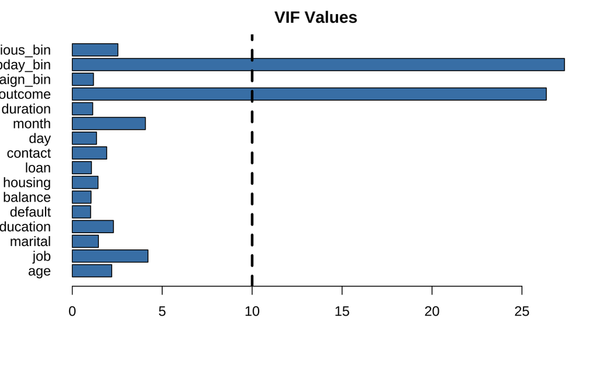

```r
vif_values <- data.frame(vif(modelv1))
barplot(vif_values$GVIF,names.arg = rownames(vif_values),las = 1, main = "VIF Values", horiz = TRUE, col = "steelblue")
#add vertical line at 5
abline(v = 10, lwd = 3, lty = 2)
```

#### removing pday_bin and remodelling

```r
modelv2 <- glm(subscribed ~ age + job + marital + education + default + balance
               + housing + loan + contact + day + month + duration + poutcome
               + campaign_bin + previous_bin, data = df_loan, family = "binomial" )
summary(modelv2)
```

```
Call:
glm(formula = subscribed ~ age + job + marital + education +
    default + balance + housing + loan + contact + day + month +
    duration + poutcome + campaign_bin + previous_bin, family = "binomial",
    data = df_loan)

Deviance Residuals:
    Min       1Q   Median       3Q      Max
-5.7548  -0.3767  -0.2526  -0.1511   3.4269

Coefficients:
                     Estimate Std. Error z value Pr(>|z|)
(Intercept)        -2.971e+00  2.076e-01 -14.309  < 2e-16 ***
age                -5.178e-04  2.640e-03  -0.196 0.844476
jobblue-collar     -3.504e-01  8.681e-02  -4.036 5.44e-05 ***
jobentrepreneur    -2.623e-01  1.495e-01  -1.754 0.079352 .
jobhousemaid       -4.285e-01  1.594e-01  -2.688 0.007186 **
jobmanagement      -1.772e-01  8.721e-02  -2.032 0.042150 *
jobretired          2.189e-01  1.164e-01   1.880 0.060068 .
jobself-employed   -2.988e-01  1.310e-01  -2.280 0.022624 *
jobservices        -2.719e-01  1.013e-01  -2.684 0.007269 **
jobstudent          3.156e-01  1.317e-01   2.397 0.016540 *
jobtechnician      -1.461e-01  8.169e-02  -1.788 0.073758 .
jobunemployed      -2.852e-01  1.377e-01  -2.071 0.038325 *
jobunknown         -3.391e-01  2.740e-01  -1.237 0.215925
maritalmarried     -1.886e-01  7.013e-02  -2.689 0.007156 **
maritalsingle       8.632e-02  8.019e-02   1.076 0.281723
educationsecondary  1.041e-01  7.726e-02   1.348 0.177799
educationtertiary   2.925e-01  8.958e-02   3.266 0.001093 **
educationunknown    1.652e-01  1.241e-01   1.331 0.183089
defaultyes          7.570e-02  1.845e-01   0.410 0.681501
balance             1.315e-05  6.253e-06   2.102 0.035531 *
housingyes         -6.631e-01  5.229e-02 -12.682  < 2e-16 ***
loanyes            -4.752e-01  7.214e-02  -6.587 4.48e-11 ***
contacttelephone   -1.952e-01  9.067e-02  -2.153 0.031294 *
contactunknown     -1.635e+00  8.710e-02 -18.767  < 2e-16 ***
day                 1.035e-02  2.986e-03   3.467 0.000527 ***
monthaug           -4.944e-01  9.401e-02  -5.259 1.45e-07 ***
monthdec            6.154e-01  2.128e-01   2.892 0.003827 **
monthfeb           -7.855e-02  1.083e-01  -0.725 0.468163
```

[output cut: 15 more lines]

```
campaign_bin^4      1.457e-01  1.341e-01   1.087 0.277024
campaign_bin^5      3.067e-02  1.333e-01   0.230 0.818046
campaign_bin^6      1.575e-01  1.215e-01   1.297 0.194775
campaign_bin^7      2.236e-02  1.119e-01   0.200 0.841648
previous_bin.L      1.249e-01  6.179e-02   2.022 0.043174 *
---
Signif. codes:  0 ‘***’ 0.001 ‘**’ 0.01 ‘*’ 0.05 ‘.’ 0.1 ‘ ’ 1

(Dispersion parameter for binomial family taken to be 1)

    Null deviance: 22893  on 31646  degrees of freedom
Residual deviance: 15133  on 31599  degrees of freedom
AIC: 15229

Number of Fisher Scoring iterations: 6
```

#### rechecking vif:

We have reconfirmed VIF in this section and confirmed that no variable is multicollinear because VIF is less than 10 in all cases.

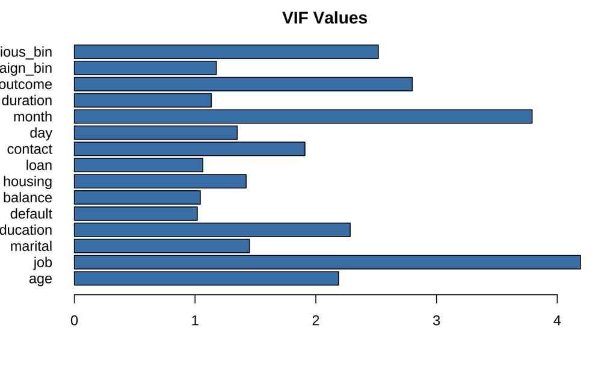

```r
vif_values <- data.frame(vif(modelv2))
barplot(vif_values$GVIF,names.arg = rownames(vif_values),las = 1, main = "VIF Values", horiz = TRUE, col = "steelblue")
#add vertical line at 5
abline(v = 10, lwd = 3, lty = 2)
```

#### removing insignificant terms

```r
modelv3 <- glm(subscribed ~ job + marital + balance
               + housing + loan + contact + day + month + duration + poutcome
               , data = df_loan, family = "binomial" )
summary(modelv3)
```

```
Call:
glm(formula = subscribed ~ job + marital + balance + housing +
    loan + contact + day + month + duration + poutcome, family = "binomial",
    data = df_loan)

Deviance Residuals:
    Min       1Q   Median       3Q      Max
-5.6565  -0.3779  -0.2587  -0.1556   3.4487

Coefficients:
                   Estimate Std. Error z value Pr(>|z|)
(Intercept)      -2.406e+00  1.358e-01 -17.720  < 2e-16 ***
jobblue-collar   -4.192e-01  8.343e-02  -5.025 5.04e-07 ***
jobentrepreneur  -2.119e-01  1.469e-01  -1.442  0.14932
jobhousemaid     -4.789e-01  1.549e-01  -3.091  0.00200 **
jobmanagement    -6.244e-02  7.571e-02  -0.825  0.40951
jobretired        2.179e-01  1.016e-01   2.144  0.03202 *
jobself-employed -2.205e-01  1.269e-01  -1.738  0.08226 .
jobservices      -3.002e-01  1.009e-01  -2.976  0.00292 **
jobstudent        3.273e-01  1.280e-01   2.558  0.01053 *
jobtechnician    -1.333e-01  8.078e-02  -1.651  0.09877 .
jobunemployed    -2.733e-01  1.366e-01  -2.001  0.04539 *
jobunknown       -3.258e-01  2.668e-01  -1.221  0.22197
maritalmarried   -2.051e-01  6.957e-02  -2.949  0.00319 **
maritalsingle     1.195e-01  7.461e-02   1.601  0.10932
balance           1.402e-05  6.174e-06   2.271  0.02314 *
housingyes       -6.675e-01  5.185e-02 -12.873  < 2e-16 ***
loanyes          -4.773e-01  7.180e-02  -6.648 2.97e-11 ***
contacttelephone -2.806e-01  8.902e-02  -3.152  0.00162 **
contactunknown   -1.648e+00  8.735e-02 -18.870  < 2e-16 ***
day               6.449e-03  2.939e-03   2.195  0.02819 *
monthaug         -6.625e-01  9.153e-02  -7.239 4.54e-13 ***
monthdec          5.286e-01  2.133e-01   2.478  0.01320 *
monthfeb         -1.539e-01  1.073e-01  -1.435  0.15127
monthjan         -1.148e+00  1.464e-01  -7.839 4.55e-15 ***
monthjul         -8.621e-01  9.265e-02  -9.305  < 2e-16 ***
monthjun          4.393e-01  1.122e-01   3.915 9.03e-05 ***
monthmar          1.608e+00  1.412e-01  11.386  < 2e-16 ***
monthmay         -3.734e-01  8.676e-02  -4.304 1.68e-05 ***
monthnov         -8.555e-01  1.015e-01  -8.430  < 2e-16 ***
monthoct          9.797e-01  1.311e-01   7.473 7.86e-14 ***
monthsep          9.085e-01  1.422e-01   6.388 1.68e-10 ***
duration          2.505e-01  4.604e-03  54.415  < 2e-16 ***
poutcomeother     1.636e-01  1.064e-01   1.537  0.12423
poutcomesuccess   2.356e+00  9.497e-02  24.807  < 2e-16 ***
poutcomeunknown  -1.462e-01  6.868e-02  -2.128  0.03331 *
---
Signif. codes:  0 ‘***’ 0.001 ‘**’ 0.01 ‘*’ 0.05 ‘.’ 0.1 ‘ ’ 1

(Dispersion parameter for binomial family taken to be 1)

    Null deviance: 22893  on 31646  degrees of freedom
Residual deviance: 15247  on 31612  degrees of freedom
AIC: 15317

Number of Fisher Scoring iterations: 6
```

#### Interaction term detection

##### Types of interaction

###### Quantitative interaction

When the direction of one outcome is independent of other variable then we have quanitaitve interaction. ###### Qualitative interaction When the direction of outcomes are opposite then we have qualitative interaction.

```r
# model_int <- glm(subscribed ~ (job + marital + balance
#                + housing + loan + contact + day + month + duration + poutcome)^2
#                , data = df_loan, family = "binomial" )
# anova(model_int,test = "Chisq")
```

#### interaction term plot: day:month

This variable has qualitative interaction as direction of months are opposite. Deviance = 385.3 for 11 degree of freedom The first interaction has been drawn by taking day and month as interacting variable versus our dependent variable, subscribed. We have found the days have significant interaction with months which affect the probability of subscription.

```
Data were 'prettified'. Consider using `terms="day [all]"` to get smooth plots.
Warning: n too large, allowed maximum for palette Set1 is 9
Returning the palette you asked for with that many colors
```

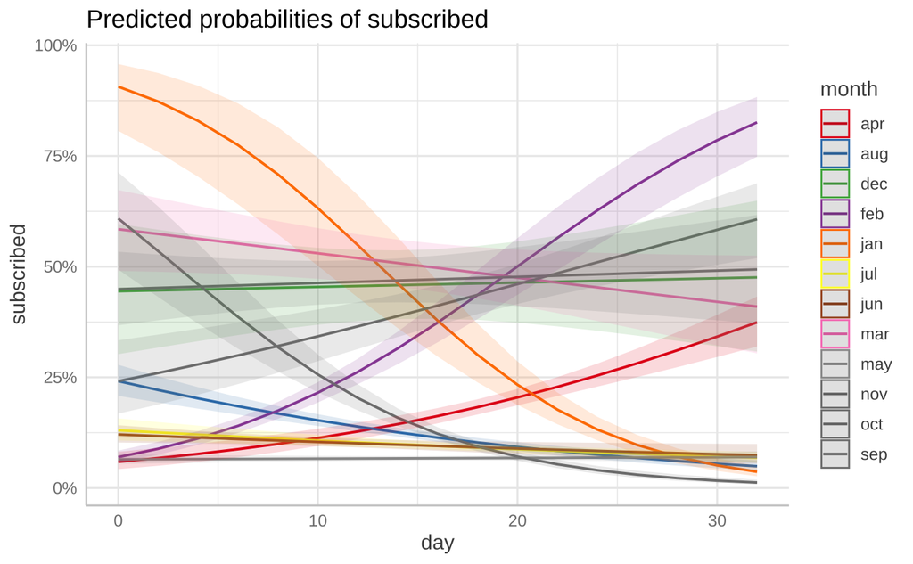

```r
model_day_month_int <- glm(subscribed ~ day*month, data = df_loan, family = "binomial" )
plot_model(model_day_month_int, type = "int")
```

#### interaction term plot: month:poutcome

In this case, the interaction is qualitative among failure, other success and unknown as these variables have opposite directions. Deviance = 318.0 for 33 degree of freedom The second interaction has been derived by considering month with poutcome. It also has high deviance and interaction plot represents that subscription is interacted with these two variables.

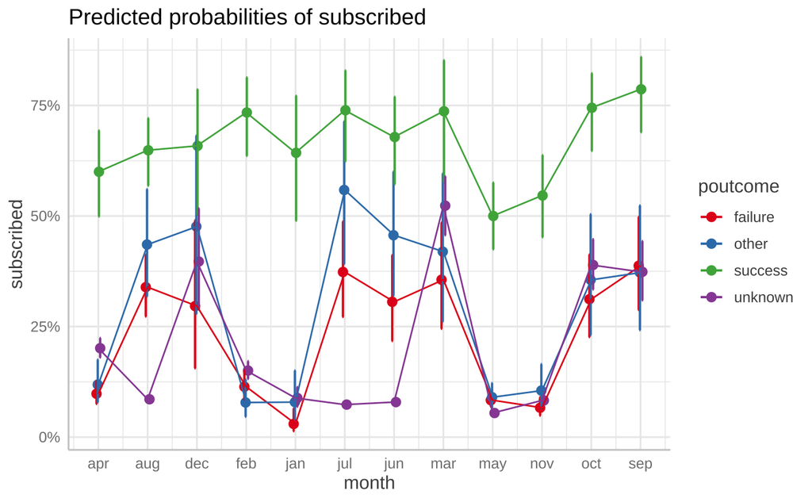

```r
model_month_pout_int <- glm(subscribed ~ month*poutcome, data = df_loan, family = "binomial" )
plot_model(model_month_pout_int, type = "int")+geom_line()
```

#### interaction term plot: job:month

The campaign has been conducted in different months so the subscription rate is different among each month. The direction of almost all months is opposite to one another. And these variables are interacting variables. Deviance = 287.4 with 121 degree of freedom

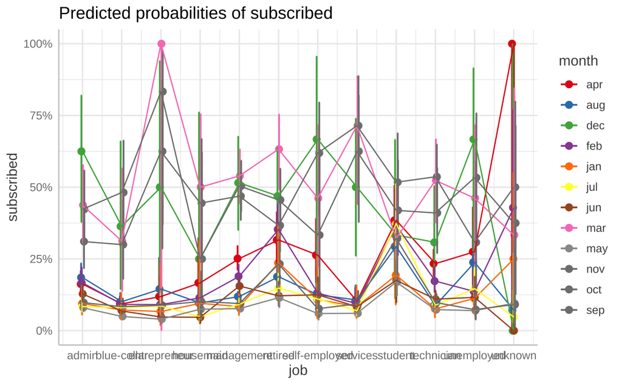

```r
model_month_job_int <- glm(subscribed ~ job*month , data = df_loan, family = "binomial" )
plot_model(model_month_job_int, type = "int")+geom_line()
```

#### Splitting dataset into 80:20

We has splited data in train and test dataset to perform elimination and validate the model. Our 80% observations goes in train dataset and 20% of observations are in test dataset.

```r
df_loan <- na.omit(df_loan)
set.seed(13)
sample <- sample.split(Y = df_loan$subscribed, SplitRatio = 0.8)
train_df <- subset(df_loan, sample == TRUE)
test_df <- subset(df_loan, sample == FALSE)
```

#### stepwise variable selections

We have checked missing values in our target value initially to validate that there is no missing value in it.

```r
sum(is.na(df_loan$subscribed))
```

```
[1] 0
```

##### backward elimination without interaction

Backward elimination is done by taking all the variables in model initially and then the model has removed insignificant variables. Here we have found three variable that are removed from the model based on high AIC value.

```r
model_interceptv1 <- glm(subscribed~1,family = 'binomial',data = train_df)
model_allv1 <- glm(subscribed~.,family = 'binomial',data = train_df)
backwardv1 <- stepAIC(model_allv1, direction='backward', scope=formula(model_allv1), trace=0)
backwardv1$anova
```

```
Stepwise Model Path
Analysis of Deviance Table

Initial Model:
subscribed ~ age + job + marital + education + default + balance +
    housing + loan + contact + day + month + duration + poutcome +
    campaign_bin + pday_bin + previous_bin

Final Model:
subscribed ~ job + marital + education + balance + housing +
    loan + contact + day + month + duration + poutcome + campaign_bin +
    pday_bin

            Step Df  Deviance Resid. Df Resid. Dev      AIC
1                                 25267   12079.15 12181.15
2          - age  1 0.2476282     25268   12079.40 12179.40
3      - default  1 0.3645957     25269   12079.77 12177.77
4 - previous_bin  1 1.8590695     25270   12081.63 12177.63
```

```r
backwardv1$coefficients
```

```
       (Intercept)     jobblue-collar    jobentrepreneur       jobhousemaid      jobmanagement         jobretired
     -3.039656e+00      -3.966952e-01      -1.401395e-01      -6.148469e-01      -1.767548e-01       1.646135e-01
  jobself-employed        jobservices         jobstudent      jobtechnician      jobunemployed         jobunknown
     -3.359920e-01      -2.583438e-01       3.185628e-01      -1.302344e-01      -3.694031e-01      -8.900355e-02
    maritalmarried      maritalsingle educationsecondary  educationtertiary   educationunknown            balance
     -1.662017e-01       9.386176e-02       1.255809e-01       2.565806e-01       1.016424e-01       1.329466e-05
        housingyes            loanyes   contacttelephone     contactunknown                day           monthaug
     -6.242678e-01      -4.115831e-01      -1.259072e-01      -1.630635e+00       1.303372e-02      -3.924899e-01
          monthdec           monthfeb           monthjan           monthjul           monthjun           monthmar
      6.938710e-01       4.633783e-02      -1.219278e+00      -7.614101e-01       5.607914e-01       1.739495e+00
          monthmay           monthnov           monthoct           monthsep           duration      poutcomeother
     -2.495328e-01      -8.040705e-01       1.018242e+00       9.224727e-01       2.550075e-01       1.330549e-01
   poutcomesuccess    poutcomeunknown     campaign_bin.L     campaign_bin.Q     campaign_bin.C     campaign_bin^4
      2.286218e+00      -1.619851e-01      -5.492298e-01       1.494050e-01      -1.320709e-01       1.008536e-01
    campaign_bin^5     campaign_bin^6     campaign_bin^7         pday_bin.L         pday_bin.Q         pday_bin.C
     -4.525583e-02       1.073490e-01       9.888683e-02      -1.800315e-01      -1.942191e-01       9.039573e-02
```

We have checked coefficients or estimates of the variables that are kept in model to see the probability of association of variables with target variables.

##### forward selection without interaction

```r
forwardv1 <- stepAIC(model_interceptv1, direction='forward', scope=formula(model_allv1), trace=0)
forwardv1$anova
```

```
Stepwise Model Path
Analysis of Deviance Table

Initial Model:
subscribed ~ 1

Final Model:
subscribed ~ duration + poutcome + month + contact + housing +
    campaign_bin + job + loan + marital + day + pday_bin + balance +
    education

             Step Df    Deviance Resid. Df Resid. Dev      AIC
1                                    25317   18314.33 18316.33
2      + duration  1 2804.840455     25316   15509.49 15513.49
3      + poutcome  3 1696.776949     25313   13812.71 13822.71
4         + month 11  909.610613     25302   12903.10 12935.10
5       + contact  2  372.288110     25300   12530.81 12566.81
6       + housing  1  178.365602     25299   12352.45 12390.45
7  + campaign_bin  7   86.491482     25292   12265.95 12317.95
8           + job 11   87.159224     25281   12178.80 12252.80
9          + loan  1   32.780474     25280   12146.02 12222.02
10      + marital  2   26.374312     25278   12119.64 12199.64
11          + day  1   16.308016     25277   12103.33 12185.33
12     + pday_bin  3   10.747432     25274   12092.59 12180.59
13      + balance  1    3.809505     25273   12088.78 12178.78
14    + education  3    7.150089     25270   12081.63 12177.63
```

```r
forwardv1$coefficients
```

```
       (Intercept)           duration      poutcomeother    poutcomesuccess    poutcomeunknown           monthaug
     -3.039656e+00       2.550075e-01       1.330549e-01       2.286218e+00      -1.619851e-01      -3.924899e-01
          monthdec           monthfeb           monthjan           monthjul           monthjun           monthmar
      6.938710e-01       4.633783e-02      -1.219278e+00      -7.614101e-01       5.607914e-01       1.739495e+00
          monthmay           monthnov           monthoct           monthsep   contacttelephone     contactunknown
     -2.495328e-01      -8.040705e-01       1.018242e+00       9.224727e-01      -1.259072e-01      -1.630635e+00
        housingyes     campaign_bin.L     campaign_bin.Q     campaign_bin.C     campaign_bin^4     campaign_bin^5
     -6.242678e-01      -5.492298e-01       1.494050e-01      -1.320709e-01       1.008536e-01      -4.525583e-02
    campaign_bin^6     campaign_bin^7     jobblue-collar    jobentrepreneur       jobhousemaid      jobmanagement
      1.073490e-01       9.888683e-02      -3.966952e-01      -1.401395e-01      -6.148469e-01      -1.767548e-01
        jobretired   jobself-employed        jobservices         jobstudent      jobtechnician      jobunemployed
      1.646135e-01      -3.359920e-01      -2.583438e-01       3.185628e-01      -1.302344e-01      -3.694031e-01
        jobunknown            loanyes     maritalmarried      maritalsingle                day         pday_bin.L
     -8.900355e-02      -4.115831e-01      -1.662017e-01       9.386176e-02       1.303372e-02      -1.800315e-01
        pday_bin.Q         pday_bin.C            balance educationsecondary  educationtertiary   educationunknown
     -1.942191e-01       9.039573e-02       1.329466e-05       1.255809e-01       2.565806e-01       1.016424e-01
```

We have again verified estimates of variables to check the probability of subscription depending upon all the variables.

##### backward elimination with interaction:

We have made backward elimination model with interaction term. This model has preserved one more variable than without interaction. Hence, the interaction term has verified that the variables can be significant because of interaction.

```r
model_interceptv2 <- glm(subscribed~1,family = 'binomial',data = train_df)
model_allv2 <- glm(subscribed~age + job + marital + education + default + balance
               + housing + loan + contact + day + month + duration + poutcome
               + campaign_bin + previous_bin + day*month,family = 'binomial',data = train_df)
backwardv2 <- stepAIC(model_allv2, direction='backward', scope=formula(model_allv2), trace=0)
backwardv2$anova
```

```
Stepwise Model Path
Analysis of Deviance Table

Initial Model:
subscribed ~ age + job + marital + education + default + balance +
    housing + loan + contact + day + month + duration + poutcome +
    campaign_bin + previous_bin + day * month

Final Model:
subscribed ~ job + marital + education + balance + housing +
    loan + contact + day + month + duration + poutcome + campaign_bin +
    previous_bin + day:month

       Step Df Deviance Resid. Df Resid. Dev      AIC
1                           25259   11679.26 11797.26
2     - age  1 0.229185     25260   11679.49 11795.49
3 - default  1 1.097895     25261   11680.59 11794.59
```

```r
backwardv2$coefficients
```

```
       (Intercept)     jobblue-collar    jobentrepreneur       jobhousemaid      jobmanagement         jobretired
     -3.761205e+00      -3.531103e-01      -6.625288e-02      -6.106478e-01      -1.596181e-01       1.151517e-01
  jobself-employed        jobservices         jobstudent      jobtechnician      jobunemployed         jobunknown
     -2.963728e-01      -2.124330e-01       2.808384e-01      -1.287409e-01      -2.821501e-01      -9.480849e-02
    maritalmarried      maritalsingle educationsecondary  educationtertiary   educationunknown            balance
     -2.052197e-01       6.079752e-02       1.348443e-01       2.663983e-01       1.238428e-01       1.114868e-05
        housingyes            loanyes   contacttelephone     contactunknown                day           monthaug
     -5.624923e-01      -4.069519e-01      -2.063207e-01      -1.898021e+00       4.692095e-02       8.357915e-01
          monthdec           monthfeb           monthjan           monthjul           monthjun           monthmar
      1.721276e+00      -2.918041e-01       5.283283e+00       4.515138e-01       1.531776e+00       3.061604e+00
          monthmay           monthnov           monthoct           monthsep           duration      poutcomeother
     -3.463910e-01       2.738099e+00       1.576407e-01       1.580522e+00       2.628355e-01       9.200311e-02
   poutcomesuccess    poutcomeunknown     campaign_bin.L     campaign_bin.Q     campaign_bin.C     campaign_bin^4
      2.255623e+00       2.190233e-03      -4.120361e-01       1.847573e-01      -1.113402e-01       1.161029e-01
    campaign_bin^5     campaign_bin^6     campaign_bin^7     previous_bin.L       day:monthaug       day:monthdec
     -4.052970e-03       1.615151e-01       1.573312e-01       1.173201e-01      -7.251321e-02      -5.620804e-02
      day:monthfeb       day:monthjan       day:monthjul       day:monthjun       day:monthmar       day:monthmay
      9.572631e-02      -2.602770e-01      -6.734708e-02      -4.848495e-02      -7.854791e-02       1.571616e-02
      day:monthnov       day:monthoct       day:monthsep
     -1.978193e-01       5.208363e-02      -2.592568e-02
```

The estimated of probability of subscription is taken to make estimates.

##### forward selection with interaction:

```r
forwardv2 <- stepAIC(model_interceptv2, direction='forward', scope=formula(model_allv2), trace=0)
forwardv2$anova
```

```
Stepwise Model Path
Analysis of Deviance Table

Initial Model:
subscribed ~ 1

Final Model:
subscribed ~ duration + poutcome + month + contact + housing +
    campaign_bin + job + loan + marital + day + education + previous_bin +
    balance + month:day

             Step Df    Deviance Resid. Df Resid. Dev      AIC
1                                    25317   18314.33 18316.33
2      + duration  1 2804.840455     25316   15509.49 15513.49
3      + poutcome  3 1696.776949     25313   13812.71 13822.71
4         + month 11  909.610613     25302   12903.10 12935.10
5       + contact  2  372.288110     25300   12530.81 12566.81
6       + housing  1  178.365602     25299   12352.45 12390.45
7  + campaign_bin  7   86.491482     25292   12265.95 12317.95
8           + job 11   87.159224     25281   12178.80 12252.80
9          + loan  1   32.780474     25280   12146.02 12222.02
10      + marital  2   26.374312     25278   12119.64 12199.64
11          + day  1   16.308016     25277   12103.33 12185.33
12    + day:month 11  410.138173     25266   11693.19 11797.19
13    + education  3    7.462771     25263   11685.73 11795.73
14 + previous_bin  1    2.778401     25262   11682.95 11794.95
15      + balance  1    2.361658     25261   11680.59 11794.59
```

```r
forwardv2$coefficients
```

```
       (Intercept)           duration      poutcomeother    poutcomesuccess    poutcomeunknown           monthaug
     -3.761205e+00       2.628355e-01       9.200311e-02       2.255623e+00       2.190233e-03       8.357915e-01
          monthdec           monthfeb           monthjan           monthjul           monthjun           monthmar
      1.721276e+00      -2.918041e-01       5.283283e+00       4.515138e-01       1.531776e+00       3.061604e+00
          monthmay           monthnov           monthoct           monthsep   contacttelephone     contactunknown
     -3.463910e-01       2.738099e+00       1.576407e-01       1.580522e+00      -2.063207e-01      -1.898021e+00
        housingyes     campaign_bin.L     campaign_bin.Q     campaign_bin.C     campaign_bin^4     campaign_bin^5
     -5.624923e-01      -4.120361e-01       1.847573e-01      -1.113402e-01       1.161029e-01      -4.052970e-03
    campaign_bin^6     campaign_bin^7     jobblue-collar    jobentrepreneur       jobhousemaid      jobmanagement
      1.615151e-01       1.573312e-01      -3.531103e-01      -6.625288e-02      -6.106478e-01      -1.596181e-01
        jobretired   jobself-employed        jobservices         jobstudent      jobtechnician      jobunemployed
      1.151517e-01      -2.963728e-01      -2.124330e-01       2.808384e-01      -1.287409e-01      -2.821501e-01
        jobunknown            loanyes     maritalmarried      maritalsingle                day educationsecondary
     -9.480849e-02      -4.069519e-01      -2.052197e-01       6.079752e-02       4.692095e-02       1.348443e-01
 educationtertiary   educationunknown     previous_bin.L            balance       monthaug:day       monthdec:day
      2.663983e-01       1.238428e-01       1.173201e-01       1.114868e-05      -7.251321e-02      -5.620804e-02
      monthfeb:day       monthjan:day       monthjul:day       monthjun:day       monthmar:day       monthmay:day
      9.572631e-02      -2.602770e-01      -6.734708e-02      -4.848495e-02      -7.854791e-02       1.571616e-02
      monthnov:day       monthoct:day       monthsep:day
     -1.978193e-01       5.208363e-02      -2.592568e-02
```

#### comparing models:

First of all we will compare our model based on AIC value as we choosed stepAIC method for variable selection. Lets understand what AIC really is. An estimate of prediction error and hence of the relative quality of statistical models for a certain set of data is the Akaike information criterion. AIC calculates the quality of each model in relation to the other models given a set of models for the data. As a result, AIC offers a model selection method.

```r
library(stats)
print("forward without interaction")
```

```
[1] "forward without interaction"
```

```r
print(AIC(forwardv1))
```

```
[1] 12177.63
```

```r
print("forward with interaction")
```

```
[1] "forward with interaction"
```

```r
print(AIC(forwardv2))
```

```
[1] 11794.59
```

```r
print("backward without interaction")
```

```
[1] "backward without interaction"
```

```r
print(AIC(backwardv1))
```

```
[1] 12177.63
```

```r
print("backward with interaction")
```

```
[1] "backward with interaction"
```

```r
print(AIC(backwardv2))
```

```
[1] 11794.59
```

Here we notice that our AIC value for backward and forward selection method without interaction term is the same. The same stands for AIC value of forward and backward elimination with interaction.

Now lets compare the different model using loglikelihood test. Here the models we will consider for analysis is our forward selection model with and without interaction. We will also use backward elimination model with and without interaction.

Lets state our hypothesis: H0: Reduced model is significant. HA: The full model is significant.

```r
library(lmtest)
lrtest(forwardv1, forwardv2)
```

```
Likelihood ratio test

Model 1: subscribed ~ duration + poutcome + month + contact + housing +
    campaign_bin + job + loan + marital + day + pday_bin + balance +
    education
Model 2: subscribed ~ duration + poutcome + month + contact + housing +
    campaign_bin + job + loan + marital + day + education + previous_bin +
    balance + month:day
  #Df  LogLik Df  Chisq Pr(>Chisq)
1  48 -6040.8
2  57 -5840.3  9 401.03  < 2.2e-16 ***
---
Signif. codes:  0 ‘***’ 0.001 ‘**’ 0.01 ‘*’ 0.05 ‘.’ 0.1 ‘ ’ 1
```

```r
lrtest(backwardv1, backwardv2)
```

```
Likelihood ratio test

Model 1: subscribed ~ job + marital + education + balance + housing +
    loan + contact + day + month + duration + poutcome + campaign_bin +
    pday_bin
Model 2: subscribed ~ job + marital + education + balance + housing +
    loan + contact + day + month + duration + poutcome + campaign_bin +
    previous_bin + day:month
  #Df  LogLik Df  Chisq Pr(>Chisq)
1  48 -6040.8
2  57 -5840.3  9 401.03  < 2.2e-16 ***
---
Signif. codes:  0 ‘***’ 0.001 ‘**’ 0.01 ‘*’ 0.05 ‘.’ 0.1 ‘ ’ 1
```

Here in both the cases our full model (model with interaction) is appropriate as p-value is less than 0.05.

For this project, we will also consider forwardv1 and forwardv2 for reference in the below questions:

#### classification report

In this following question, we will calculate classification report and multiple classification metrics like accuracy, specificity, sensitivity etc.

```r
#### forwardv2

test_df_sub_forv2 <- subset(test_df,select = c(subscribed,duration,poutcome,month,contact,housing
                          ,campaign_bin,job,loan,marital,day,education,previous_bin,balance))

glm_probs_forv2 = data.frame(probs <- predict(forwardv2,test_df_sub_forv2,type = "response"))

library(dplyr)
glm_pred_forv2 = glm_probs_forv2 %>%
  mutate(pred = ifelse(probs>.5, "yes", "no"))

glm_pred_forv2$pred <- factor(glm_pred_forv2$pred)

print("classification report: ")
```

```
[1] "classification report: "
```

```r
caret::confusionMatrix(glm_pred_forv2$pred,test_df$subscribed)
```

```
Confusion Matrix and Statistics

          Reference
Prediction   no  yes
       no  5445  467
       yes  141  276

               Accuracy : 0.9039
                 95% CI : (0.8964, 0.9111)
    No Information Rate : 0.8826
    P-Value [Acc > NIR] : 3.397e-08

                  Kappa : 0.4275

 Mcnemar's Test P-Value : < 2.2e-16

            Sensitivity : 0.9748
            Specificity : 0.3715
         Pos Pred Value : 0.9210
         Neg Pred Value : 0.6619
             Prevalence : 0.8826
         Detection Rate : 0.8603
   Detection Prevalence : 0.9341
      Balanced Accuracy : 0.6731

       'Positive' Class : no
```

Classification Report of model with interaction: Here the overall accuracy is 0.9039. This might be misleading because our dataset response variable is imbalance. Due to this our model is more biased on “No” class which has more datapoints. When observed, we have Sensitivity = 0.9748 whereas the Specificity = 0.3715 . This discrepancy between sensitivity and specificity is because of huge data counts between yes and no (subscribe variable). Our balanced accuracy considering the imbalance data is 0.6731. This model is better overall than other models.Here our positive reference class is “no”.

```r
#### forwardv1

test_df_sub_forv1 <- subset(test_df,select = c(job, marital, education, balance
    , housing, loan, contact, day, month, duration, poutcome, campaign_bin,
    pday_bin,previous_bin))

glm_probs_forv1 = data.frame(probs <- predict(forwardv1,test_df_sub_forv1,type = "response"))

glm_pred_forv1 = glm_probs_forv1 %>%
  mutate(pred = ifelse(probs>.5, "yes", "no"))

glm_pred_forv1$pred <- factor(glm_pred_forv1$pred)

print("classification report: ")
```

```
[1] "classification report: "
```

```r
caret::confusionMatrix(glm_pred_forv1$pred,test_df$subscribed)
```

```
Confusion Matrix and Statistics

          Reference
Prediction   no  yes
       no  5456  491
       yes  130  252

               Accuracy : 0.9019
                 95% CI : (0.8943, 0.9091)
    No Information Rate : 0.8826
    P-Value [Acc > NIR] : 5.858e-07

                  Kappa : 0.4002

 Mcnemar's Test P-Value : < 2.2e-16

            Sensitivity : 0.9767
            Specificity : 0.3392
         Pos Pred Value : 0.9174
         Neg Pred Value : 0.6597
             Prevalence : 0.8826
         Detection Rate : 0.8621
   Detection Prevalence : 0.9396
      Balanced Accuracy : 0.6579

       'Positive' Class : no
```

#### AUC the ROC curve:

Now we will calculate Area Under Curve (AUC) for forward selection model with and without interaction.

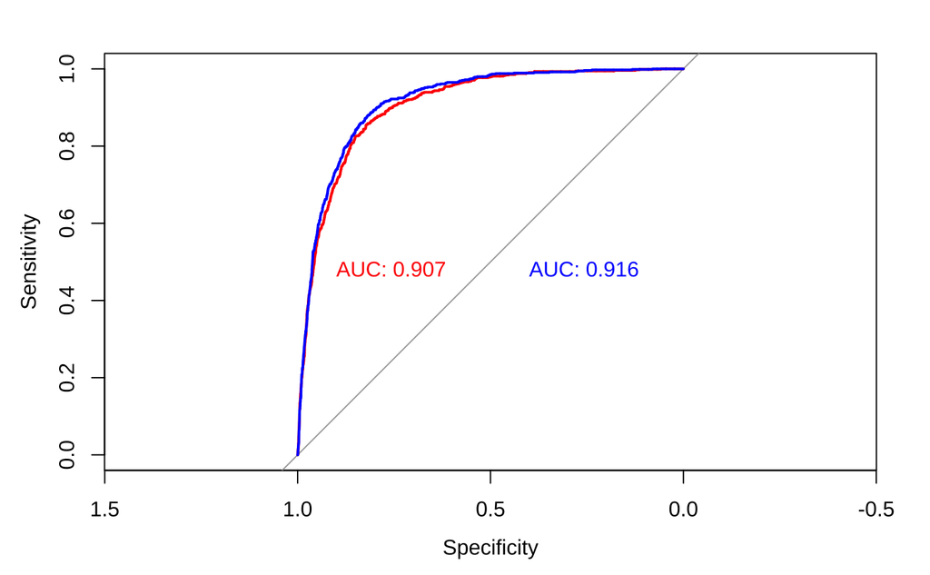

```r
#### forwardv1
library(pROC)
probsv1 <- predict(forwardv1,test_df_sub_forv1,type = "response")
test_rocv1 = roc(test_df$subscribed ~ probsv1, plot = FALSE, print.auc = FALSE)
#### forwardv2
probsv2 <- predict(forwardv2,test_df_sub_forv2,type = "response")
test_rocv2 = roc(test_df$subscribed ~ probsv2, plot = FALSE, print.auc = FALSE)
plot(test_rocv1, colorize = TRUE,print.auc = TRUE,col="red",print.auc.x = 0.9,
     print.auc.y = 0.5)
plot(test_rocv2, add = TRUE, col="blue",print.auc = TRUE,print.auc.x = 0.4)
```

The performance of a classification model through each classification threshold is depicted on a graph called a receiver operating characteristic curve (ROC).

Here the forward selection model with interaction has an AUC score of 0.916 whereas the model without interaction has an AUC score of 0.907.

#### Lack of fit test (Hosmer-Lemshow test- ungrouped data):

```r
library(glmtoolbox)

hltest(forwardv1, verbose = TRUE)
```

```
   The Hosmer-Lemeshow goodness-of-fit test

 Group Size Observed Expected
     1 2532        5    1.623
     2 2532        5    3.243
     3 2532        7    5.047
     4 2532       17    7.145
     5 2532       49    9.583
     6 2532       81   12.767
     7 2532      156   17.830
     8 2532      361   28.086
     9 2532      804   55.924
    10 2530     1487  155.854

         Statistic =  27969.02
degrees of freedom =  8
           p-value =  < 2.22e-16
```

```r
hltest(forwardv2, verbose = TRUE)
```

```
   The Hosmer-Lemeshow goodness-of-fit test

 Group Size Observed Expected
     1 2532        6    1.375
     2 2532        1    2.888
     3 2532        5    4.438
     4 2532       10    6.218
     5 2532       43    8.440
     6 2532       70   11.479
     7 2532      131   16.590
     8 2532      352   27.482
     9 2532      816   57.950
    10 2530     1538  160.237

         Statistic =  27925
degrees of freedom =  8
           p-value =  < 2.22e-16
```

The Hosmer-Lemeshow test is a statistical test evaluating the logistic regression model’s goodness of fit.

Th hypothesis:

H0: The model is a good fit for the data H1: The model is not a good fit.

here based on 10 sample group size, both the model’s observed value is not equal to expected value. Even the p value for both model’s lack of fit test is less than 0.05 stating that we reject null hypothesis. Hence our model doesn’t fit the data properly.

#### Recommendation and conclusion:

- From the intensive EDA, it is evident that our dataset is imbalance. The response variable “subscribe” have two levels : Yes and No. level “No” has 27932 datapoints whereas level “yes” has 3715 datapoints. Because of such discrepancy in data count between two levels, we saw our model was more biased towards the class “No” than “Yes”. Our overall accuracy for the model with interaction was good but when considered altogether, the balanced accuracy and specificity were below average.
- Beacause we find such imbalance in our dataset, we could use resampling techniques to upsample or downsample the data counts of our levels making it balance. That will reduce the model being biased on higher count level.
- Another important step to handle data imbalance in our modelling is to filter our low variance columns. We can calculate the variance explained by each column on target variable using Principal Component Analysis. PCA is an important algorithm that calculate the variance of each column. Based on the PCA value, we can remove low PCA columns and consider the higher and significant one for modelling.
- Moreover, here in this project we used baseline simple logistic regression for our modelling. Given the fact that there are non-linear relationship of independent variable with target variable. Other complex model such as Random Forest and XGBoost could a better choice. They are designed to handle imbalance data and reduce bias overall.
- Last but not the least, we can normalize the overall numerical variablein our dataset which would lead the model to have better training and accuracy.

#### saving cleaned CSV

```r
write.csv(test_df_sub_forv1,'test_forwardv1.csv')
write.csv(test_df_sub_forv2,'test_forwardv2.csv')
```